# Analysis on job vacancies in Singapore

Tay Jiakang, Mila

1/2022

## R Markdown

This is a sample report on the trends of unemployment in Singapore. We will try to determine the current employment siutation in Singapore based on data obtained from the government database

## Describing the data set

The data contains job vacancies From the dataset, we have a total of 381 values. The headers are quarter, occupation, job_vacancy

## Overview of data

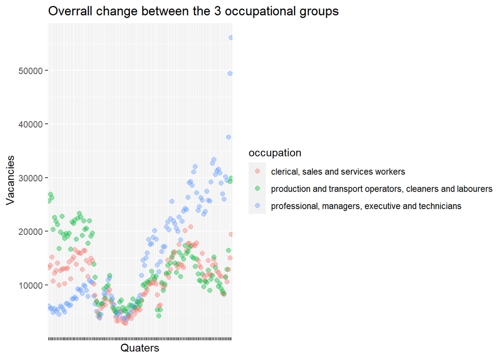

We notice that at the end of the graph, we have a large uptick, we will seek to find out more on the reason behind it.

[figure not shown]

We notice that there is a significant uptick starting in 2020 Q4. We seek secondary data for possible explanations. [Straits Times article](https://www.straitstimes.com/singapore/jobs/job-vacancies-in-singapore-hit-record-high-of-92100-in-june-mom) This suggests that it is likely due to border restrictions resulting in less foreign talents to meet the industry demands,

## Exploring unemployment rates

We shall seek to determine the severity of the situation using the ratio of job vacancies to those that are unemployed.

[figure not shown]

## Summary

The graph shows that from 2020 Q2 , there has been an increase in vacancies for those that are unemployed, corssing the 1.0 in approximately Q1 2021. This suggests that it could be an issue since there are now more vacancies that those that are unemployed. More research should be conducted to deteremine the possible impact on Singapore.